# Prediction Assignment Writeup

Hila Shamoon

## Background

Using devices such as Jawbone Up, Nike FuelBand, and Fitbit it is now possible to collect a large amount of data about personal activity relatively inexpensively. These type of devices are part of the quantified self movement – a group of enthusiasts who take measurements about themselves regularly to improve their health, to find patterns in their behavior, or because they are tech geeks. One thing that people regularly do is quantify how much of a particular activity they do, but they rarely quantify how well they do it. In this project, your goal will be to use data from accelerometers on the belt, forearm, arm, and dumbell of 6 participants. They were asked to perform barbell lifts correctly and incorrectly in 5 different ways. More information is available from the website here: http://groupware.les.inf.puc-rio.br/har (see the section on the Weight Lifting Exercise Dataset).

### Project goal

The goal of the project is to predict the manner in which each participant exercised.

### Data

The training data for this project are available here: https://d396qusza40orc.cloudfront.net/predmachlearn/pml-training.csv

The test data are available here: https://d396qusza40orc.cloudfront.net/predmachlearn/pml-testing.csv

The data for this project come from this source: http://groupware.les.inf.puc-rio.br/har.

```r
setInternet2(TRUE)
download.file(url = "https://d396qusza40orc.cloudfront.net/predmachlearn/pml-training.csv", destfile = "pml-training.csv")
download.file(url = "https://d396qusza40orc.cloudfront.net/predmachlearn/pml-testing.csv", destfile = "pml-testing.csv")
train <- read.csv('pml-training.csv')
test <- read.csv('pml-testing.csv')
```

### Class definition

- Exactly according to the specification (Class A)
- Throwing the elbows to the front (Class B)
- Lifting the dumbbell only halfway (Class C)
- Lowering the dumbbell only halfway (Class D)
- Throwing the hips to the front (Class E)

### Packages

```r
library(caret)
library(randomForest)
library(dplyr)
```

### Clean data

Remove columns that do not contribute to the analysis: * Columns that are >=95% empty *Cleaning NearZeroVariance Variables Run* Removing first colums

```r
train <- train[, 6:dim(train)[2]]

treshold <- dim(train)[1] * 0.95
#Remove columns with more than 95% of NA or "" values
xx <- !apply(train, 2, function(x) sum(is.na(x)) > treshold  || sum(x=="") > treshold)

train <- train[, xx]

yy <- nearZeroVar(train, saveMetrics = TRUE)

train <- train[, yy$nzv==FALSE]

names(train)
```

```
##  [1] "num_window"           "roll_belt"            "pitch_belt"
##  [4] "yaw_belt"             "total_accel_belt"     "gyros_belt_x"
##  [7] "gyros_belt_y"         "gyros_belt_z"         "accel_belt_x"
## [10] "accel_belt_y"         "accel_belt_z"         "magnet_belt_x"
## [13] "magnet_belt_y"        "magnet_belt_z"        "roll_arm"
## [16] "pitch_arm"            "yaw_arm"              "total_accel_arm"
## [19] "gyros_arm_x"          "gyros_arm_y"          "gyros_arm_z"
## [22] "accel_arm_x"          "accel_arm_y"          "accel_arm_z"
## [25] "magnet_arm_x"         "magnet_arm_y"         "magnet_arm_z"
## [28] "roll_dumbbell"        "pitch_dumbbell"       "yaw_dumbbell"
## [31] "total_accel_dumbbell" "gyros_dumbbell_x"     "gyros_dumbbell_y"
## [34] "gyros_dumbbell_z"     "accel_dumbbell_x"     "accel_dumbbell_y"
## [37] "accel_dumbbell_z"     "magnet_dumbbell_x"    "magnet_dumbbell_y"
## [40] "magnet_dumbbell_z"    "roll_forearm"         "pitch_forearm"
## [43] "yaw_forearm"          "total_accel_forearm"  "gyros_forearm_x"
## [46] "gyros_forearm_y"      "gyros_forearm_z"      "accel_forearm_x"
## [49] "accel_forearm_y"      "accel_forearm_z"      "magnet_forearm_x"
## [52] "magnet_forearm_y"     "magnet_forearm_z"     "classe"
```

```r
#Class variable as a factor

train$classe <- as.factor(train$classe)
```

### Set up the overall training parameters

```r
ctrl <- trainControl(method="repeatedcv", number=5, repeats=3, selectionFunction = "oneSE")
inTrain <- createDataPartition(train$classe, p=.6, list=FALSE)
training <- train[inTrain,]
testing <- train[-inTrain,]
```

### Model selection

Selecting between random forest and a generalized boosted model

```r
rf_fm <- train(classe ~ . , data=training, method="rf", metric="Kappa",
            trControl=ctrl)

gbm_fm <- train(classe ~ ., data=training, method="gbm", metric="Kappa",
            trControl=ctrl, verbose=FALSE)
```

return models

#### random forest

```r
rf_fm
```

```
## Random Forest
##
## 11776 samples
##    53 predictor
##     5 classes: 'A', 'B', 'C', 'D', 'E'
##
## No pre-processing
## Resampling: Cross-Validated (5 fold, repeated 3 times)
## Summary of sample sizes: 9420, 9421, 9420, 9420, 9423, 9420, ...
## Resampling results across tuning parameters:
##
##   mtry  Accuracy   Kappa      Accuracy SD  Kappa SD
##    2    0.9917628  0.9895791  0.001938023  0.002452157
##   27    0.9959522  0.9948795  0.002035288  0.002575265
##   53    0.9942257  0.9926956  0.002601132  0.003290722
##
## Kappa was used to select the optimal model using  the one SE rule.
## The final value used for the model was mtry = 27.
```

#### generalized boosted model

```r
gbm_fm
```

```
## Stochastic Gradient Boosting
##
## 11776 samples
##    53 predictor
##     5 classes: 'A', 'B', 'C', 'D', 'E'
##
## No pre-processing
## Resampling: Cross-Validated (5 fold, repeated 3 times)
## Summary of sample sizes: 9421, 9421, 9421, 9420, 9421, 9421, ...
## Resampling results across tuning parameters:
##
##   interaction.depth  n.trees  Accuracy   Kappa      Accuracy SD
##   1                   50      0.7593692  0.6946563  0.007902939
##   1                  100      0.8304177  0.7852847  0.010966242
##   1                  150      0.8697346  0.8351336  0.009506956
##   2                   50      0.8858693  0.8555025  0.009948959
##   2                  100      0.9404719  0.9246760  0.006364051
##   2                  150      0.9621546  0.9521169  0.005205221
##   3                   50      0.9343580  0.9169034  0.005992371
##   3                  100      0.9692026  0.9610300  0.003929444
##   3                  150      0.9832146  0.9787653  0.003212336
##   Kappa SD
##   0.009973551
##   0.013819561
##   0.012012596
##   0.012569911
##   0.008043799
##   0.006583081
##   0.007593219
##   0.004971491
##   0.004064748
##
## Tuning parameter 'shrinkage' was held constant at a value of 0.1
##
## Tuning parameter 'n.minobsinnode' was held constant at a value of 10
## Kappa was used to select the optimal model using  the one SE rule.
## The final values used for the model were n.trees = 150,
##  interaction.depth = 3, shrinkage = 0.1 and n.minobsinnode = 10.
```

#### Comparing between the two models

```r
resampls = resamples(list(RF = rf_fm,
                          GBM = gbm_fm))

difValues = diff(resampls)
summary(difValues)
```

```
##
## Call:
## summary.diff.resamples(object = difValues)
##
## p-value adjustment: bonferroni
## Upper diagonal: estimates of the difference
## Lower diagonal: p-value for H0: difference = 0
##
## Accuracy
##     RF       GBM
## RF           0.01274
## GBM 8.12e-09
##
## Kappa
##     RF       GBM
## RF           0.01611
## GBM 8.14e-09
```

Randomforest preformed better and was more accurate than the generalized boosted model.

Test the model

```r
testing$pred <- predict(rf_fm,testing, "raw")
confusionMatrix(testing$pred, testing$classe)
```

```
## Confusion Matrix and Statistics
##
##           Reference
## Prediction    A    B    C    D    E
##          A 2230   11    0    0    0
##          B    1 1506    1    0    0
##          C    0    0 1367    4    0
##          D    0    1    0 1281    0
##          E    1    0    0    1 1442
##
## Overall Statistics
##
##                Accuracy : 0.9975
##                  95% CI : (0.9961, 0.9984)
##     No Information Rate : 0.2845
##     P-Value [Acc > NIR] : < 2.2e-16
##
##                   Kappa : 0.9968
##  Mcnemar's Test P-Value : NA
##
## Statistics by Class:
##
##                      Class: A Class: B Class: C Class: D Class: E
## Sensitivity            0.9991   0.9921   0.9993   0.9961   1.0000
## Specificity            0.9980   0.9997   0.9994   0.9998   0.9997
## Pos Pred Value         0.9951   0.9987   0.9971   0.9992   0.9986
## Neg Pred Value         0.9996   0.9981   0.9998   0.9992   1.0000
## Prevalence             0.2845   0.1935   0.1744   0.1639   0.1838
## Detection Rate         0.2842   0.1919   0.1742   0.1633   0.1838
## Detection Prevalence   0.2856   0.1922   0.1747   0.1634   0.1840
## Balanced Accuracy      0.9986   0.9959   0.9993   0.9980   0.9998
```

Calculate variable importance

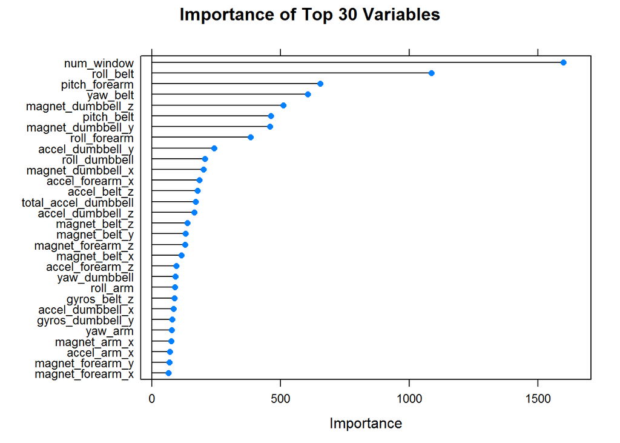

```r
varImp <- varImp(rf_fm, scale=FALSE)
plot(varImp, main = "Importance of Top 30 Variables", top = 30)
```

Predict on sample 20 of the given test csv file

```r
test_pred <- predict(rf_fm,test)
test_pred
```

```
##  [1] B A B A A E D B A A B C B A E E A B B B
## Levels: A B C D E
```

```r
# Write files for submission
pml_write_files = function(x){
  n = length(x)
  for(i in 1:n){
    filename = paste0("problem_id_",i,".txt")
    write.table(x[i],file=filename,quote=FALSE,row.names=FALSE,col.names=FALSE)
  }
}
pml_write_files(test_pred)
```

test_pred [1] B A B A A E D B A A B C B A E E A B B B Levels: A B C D E